# UNIDAD CENTINELA DE INFECCIÓN RESPIRATORIA AGUDA GRAVE (UC-IRAG)

Hospital Señor del Milagro – Provincia de Salta

Autores/as

Dr. Adrián Edelcopp

Lic. Natalia Pastrana

Fecha de publicación

28 de noviembre de 2025

### INTRODUCCIÓN

Las infecciones respiratorias agudas (IRAs) constituyen una causa relevante de morbimortalidad, especialmente en niños menores de cinco años, adultos mayores y personas con enfermedades crónicas o inmunosupresión.

La vigilancia de virus respiratorios con potencial epidémico y pandémico —como SARS-CoV-2, influenza y virus sincicial respiratorio (VSR)— resulta fundamental para caracterizar la situación epidemiológica, identificar eventos inusuales y orientar la implementación de medidas de prevención y control.

En la República Argentina, la estrategia de vigilancia de IRAs se estructura en tres componentes, entre los cuales se destaca la vigilancia centinela. Esta última permite recolectar datos de manera sistemática y oportuna en un número limitado de establecimientos, seleccionados bajo criterios predefinidos.

La provincia de Salta, forma parte de la **Red Argentina de UC-IRAG**, dicha estrategia viene implementándose desde la semana epidemiológica (SE) 18 del año 2024 en dos instituciones de referencia: el **Hospital Señor del Milagro**, ubicado en la ciudad de Salta, y el **Hospital San Vicente de Paul,** ubicado en la ciudad de Orán. Cabe destacar que el Hospital Señor del Milagro es un establecimiento orientado a la atención de población adulta a partir de los 15 años y el Hospital San Vicente de Paul brinda atención tanto a población pediátrica como adultos. **(Mapa N° 1)**

###### MAPA 1. Geolocalización de los efectores pertenecientes a la Red Nacional de UC-IRAG de la provincia de Salta.

[interactive chart not shown]

**Fuente:** Elaboración propia en base a datos del Sistema Nacional de Vigilancia de la Salud (SNVS 2.0) y jurisdicción.

### OBJETIVO DEL ANÁLISIS

Describir el perfil clínico, epidemiológico y de diagnóstico etiológico de las infecciones respiratorias agudas graves (IRAG).

### DEFINICIONES DE CASO

- **Infección Respiratoria Aguda Grave (IRAG):** Paciente de cualquier edad con infección respiratoria aguda con:
  - Fiebre referida o constatada >= 38°C; y
  - Tos; y
  - Inicio del cuadro en los 10 días precedentes; y
  - Requerimiento de internación por criterio clínico
- **Infección Respiratoria Aguda Grave (IRAG) extendida en < 2 años y >= 60 años:**
  - Infección respiratoria: definida por tos o dificultad respiratoria; e
  - Inicio del cuadro en los 10 días precedentes; y
  - Requerimiento de internación por criterio clínico

**En lactantes menores de 6 meses también considerar:**

- Apnea (cese temporal de la respiración por cualquier causa), o
- Sepsis (fiebre/hipotermia) y shock y gravemente enfermo sin causa aparente

*Para mayor información de la estrategia de vigilancia centinela de IRAG consultar en: https://www.argentina.gob.ar/sites/default/files/guia-uc-irag-vff.pdf*

### NOTA METODOLÓGICA

En el presente informe se describe la situación epidemiológica de las Infecciones Respiratorias Agudas Graves (IRAG) correspondiente a la Unidad Centinela del Hospital Señor del Milagro. El análisis integra información proveniente de dos fuentes de notificación: (1) notificación nominal y (2) notificación agrupada.

El procesamiento y análisis de los datos se efectuó con el software R, versión 4.4.1, empleando procedimientos reproducibles**.** El período evaluado abarca desde la SE 1 hasta la SE 44, tomando como fecha de corte la última SE completa disponible al momento de la elaboración del informe.

Cuando se aplicaron gráficos específicos —como el análisis de intersecciones mediante gráficos *UpSet*— se implementaron criterios de depuración orientados a garantizar la validez de las estimaciones, incluyendo la exclusión de combinaciones con baja frecuencia.

### SITUACIÓN EPIDEMIOLÓGICA

Entre la semana epidemiológica 1 y la SE 44 del año 2025, se registraron un total de 785 internaciones con diagnóstico de infeccion respiratoria aguda grave (IRAG e IRAG extendida). Del total, el 66% (n = 517) corresponden a IRAG y el 34% (n = 268) a IRAG extendida. En promedio, se notificaron 18 casos por semana.

El **Gráfico N°1** se observa un aumento sostenido de casos desde la SE 12 hasta alcanzar un período de máxima actividad concentrado entre la SE 14 y SE 23 con un pico en la SE 21 en la cual se presentaron un total de 37 casos .

###### GRÁFICO 1. Casos de IRAG e IRAG extendida por SE. Desde SE 1/2025 hasta SE 44/2025. UC IRAG-Hospital Señor Del Milagro. Provincia de Salta. N= 785

[interactive chart not shown]

El mayor número de casos de IRAG se observa en el grupo de 55 a 59 años, con 74 casos, mientras que en IRAG extendida, la mayor concentración de casos se encuentra en el grupo de edad 75 y más años, con 82 casos.

La tasa de letalidad muestra un comportamiento ascendente con la edad, alcanzando su valor más alto en el grupo de edad 75 y más años (20%), lo que refleja un riesgo significativamente mayor de desenlace fatal en adultos mayores **(Gráfico N°2**).

###### GRÁFICO 2. Casos de IRAG e IRAG extendida y tasa de letalidad por grupo de edad. Desde SE 1/2025 hasta SE 44/2025. UC IRAG-Hospital Señor Del Milagro. Provincia de Salta. N= 785

[interactive chart not shown]

### CARACTERIZACIÓN DE DETERMINACIONES DE LABORATORIO

En relación al perfil etiológico de los casos de IRAG por semana epidemiológica **(Gráfico N°3)** , se observa que la mayoría de los casos resultaron negativos para los virus estudiados. Entre los casos positivos, se registraron 175 casos, de los cuales 98 corresponden a influenza, 56 a VSR y 21 a SARS-Cov-2.

Influenza presentó su mayor actividad entre las semanas 13 y 21, con un pico en la semana 19, mientras que el virus sincicial respiratorio (VSR) mostró mayor circulación entre las semanas 20 y 27. Las determinaciones de SARS-Cov-2 se concentran en las últimas semanas.

###### GRÁFICO 3. Número de determinaciones de Influenza, VSR y SARS-Cov-2 en casos notificados de IRAG/IRAG extendida, por SE. Desde SE 1/2025 hasta SE 44/2025. UC IRAG-Hospital Señor Del Milagro. Provincia de Salta. N= 785

[interactive chart not shown]

En el **Gráfico N°4** se observa que la influenza predominó en la mayoría de los grupos de edad, mientras que en el caso de virus sincicial respiratorio (VSR) presentó mayor incidencia en personas de 50 o más años.

###### GRÁFICO 4. Número de determinaciones positivas en casos notificados de IRAG/IRAG extendida por grupo de edad. Desde SE 1 /2025 hasta SE 44 /2025. UC IRAG-Hospital Señor Del Milagro. Provincia de Salta. N= 175

[interactive chart not shown]

### CARACTERIZACIÓN CLÍNICA Y COMORBILIDADES

El **Gráfico N°5** presenta un análisis de los signos y síntomas reportados en los casos de IRAG e IRAG extendida.

###### GRÁFICO 5. Frecuencia y combinaciones de signos y síntomas registrados en casos de IRAG/IRAG extendida. Desde SE 1/2025 hasta SE 44/2025. UC IRAG-Hospital Señor Del Milagro. Provincia de Salta. N=136

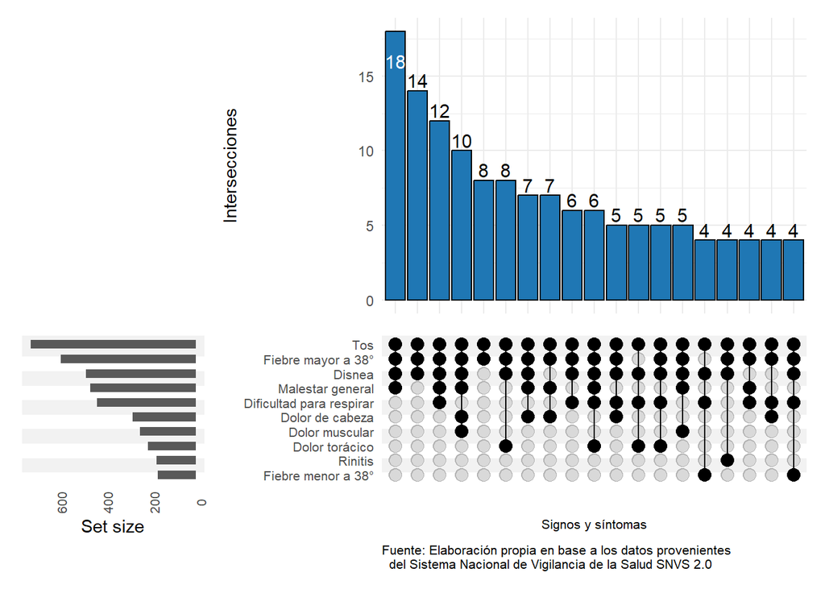

*Se excluyeron las intersecciones con frecuencia igual o menor a tres casos y aquellas que involucraban más de 6 combinaciones de síntomas (649 casos).

Se observa que la combinación sintomática más reportada fue la presencia conjunta de tos,fiebre mayor a 38°,disnea,malestar general, registrada en 18 pacientes, seguida de otras intersecciones frecuentes que incluyen tos,fiebre mayor a 38°,disnea y tos,fiebre mayor a 38°,disnea,dificultad para respirar,malestar general con 14 y 12 casos respectivamente.

En el **Gráfico N°6** se muestra la frecuencia y combinación de comorbilidades en todos los casos registrados de IRAG e IRAG extendida.

###### GRÁFICO 6. Frecuencia y combinaciones de comorbilidades registradas en casos de IRAG/IRAG extendida. Desde SE 1 /2025 hasta SE 44 /2025. UC IRAG-Hospital Señor Del Milagro. Provincia de Salta. N=601

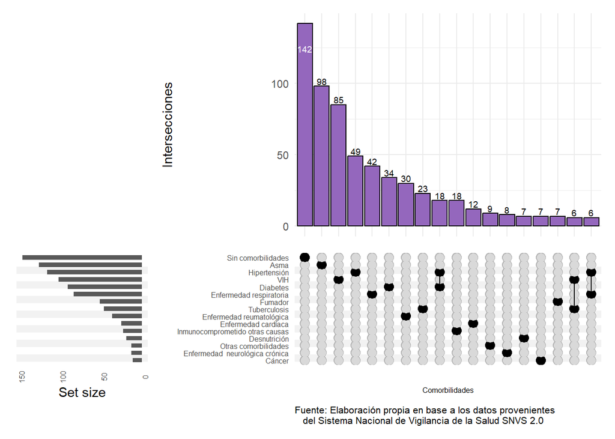

*Se excluyeron las intersecciones de comorbilidades con frecuencia igual o menor a cinco casos.

Se observa que la mayor frecuencia fue de pacientes sin comorbilidades con un total de 142 casos, seguido de asma, vih y hipertensión.

El **Gráfico N°7** muestra la frecuencia y combinación de comorbilidades en los casos fallecidos de IRAG e IRAG extendida que tuvieron laboratorio positivo para Influenza, Covid-19 y VSR.

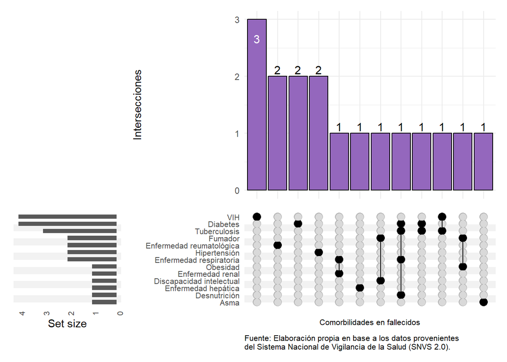

### CARACTERIZACIÓN DE INTERNACIONES

El **Gráfico N°8** muestra un incremento en la proporción de las internaciones por IRAG entre las semanas 13 y 25. Posteriormente, a partir de la semana 26, se observa un descenso gradual en la participación de casos de IRAG e IRAG extendida, mientras aumentan las internaciones por otras causas. En la mayoría de las semanas, la categoría “otras causas” mantiene un predominio relativo sobre las IRAG.

###### GRÁFICO 8. Distribución porcentual de internaciones por IRAG, IRAG extendida y otras causas. Desde SE 1/2025 hasta SE 38/2025. UC IRAG-Hospital Señor Del Milagro. Provincia de Salta. N=2527

[interactive chart not shown]

En el **Gráfico N°9** se observa que las internaciones en la unidad de cuidados intensivos (UCI) por casos de IRAG e IRAG extendida presentan una marcada variabilidad intersemanal, con semanas en las que el 100% de los pacientes internados corresponden a estos casos. A partir de la semana 29 se evidencia una disminución progresiva en la proporción de internaciones en UCI por IRAG, mientras aumentan las hospitalizaciones por otras causas. En conjunto, el gráfico muestra que las infecciones respiratorias representan una carga importante de internaciones en cuidados intensivos, con predominio de IRAG sobre IRAG extendida.

###### GRÁFICO 9. Distribución porcentual de internaciones en unidad de cuidados intensivos por IRAG, IRAG extendida y otras causas. Desde SE 1/2025 hasta SE 38/2025. UC IRAG-Hospital Señor Del Milagro. Provincia de Salta. N=247

[interactive chart not shown]

El total de defunciones por todas las causas entre la SE 1 y la SE 38 fue de 131, de las cuales 9 fueron por IRAG y 9 fueron por IRAG extendida **(Gráfico N°10)**.

###### GRAFICO 10. Distribución absoluta de defunciones por IRAG, IRAG extendida y otras causas. Desde SE 1/2025 hasta SE 38/2025. UC IRAG-Hospital Señor Del Milagro. Provincia de Salta. N= 131

[interactive chart not shown]

Actualmente se continúa trabajando en la profundización del análisis epidemiológico y en la actualización permanente del presente informe, conforme se disponga de nueva información. Ante cualquier consulta o requerimiento adicional, puede comunicarse con el **Programa de Vigilancia Epidemiológica de la Dirección General de Coordinación Epidemiológica (DGCE) a través del correo electrónico: vigiepide@gmail.com**